# **EasyVisa_Predicting Visa Approval Outcomes Using Advanced Machine Learning Techniques**

## **Hyperparameter Tuning of the XGBoost Classifier**

```python
# Measuring execution time for XGBoost tuning
%%time

# Initializing XGBoost Classifier
xgboost_classifier_tuned = XGBClassifier(random_state = 42)

# Defining hyperparameter grid for GridSearchCV
param_grid = {
    'n_estimators': np.arange(100, 301, 100),
    'learning_rate': np.arange(0.05, 0.16, 0.05),
    'max_depth': np.arange(3, 6, 1),
    'subsample': np.arange(0.8, 1.01, 0.1),
    'colsample_bytree': np.arange(0.8, 1.01, 0.1),
    'scale_pos_weight': [1, 2, 3]
}

# Creating F1 score as the evaluation metric
acc_scorer = metrics.make_scorer(metrics.f1_score)

# Setting up GridSearchCV for exhaustive hyperparameter tuning
grid_search = GridSearchCV(
    xgboost_classifier_tuned,
    param_grid,
    scoring = acc_scorer,
    cv =5,
    n_jobs = -1,
    verbose =2
)

# Fitting grid search on training data
grid_search.fit(X_train, y_train)

# Selecting the best tuned XGBoost Classifier
xgboost_classifier_tuned = grid_search.best_estimator_

# Training the best model on training data
xgboost_classifier_tuned.fit(X_train, y_train)
```

```
Fitting 5 folds for each of 729 candidates, totalling 3645 fits
CPU times: user 26.6 s, sys: 28.4 s, total: 55 s
Wall time: 24min 37s
```

```
XGBClassifier(base_score=None, booster=None, callbacks=None,
              colsample_bylevel=None, colsample_bynode=None,
              colsample_bytree=np.float64(0.9), device=None,
              early_stopping_rounds=None, enable_categorical=False,
              eval_metric=None, feature_types=None, feature_weights=None,
              gamma=None, grow_policy=None, importance_type=None,
              interaction_constraints=None, learning_rate=np.float64(0.05),
              max_bin=None, max_cat_threshold=None, max_cat_to_onehot=None,
              max_delta_step=None, max_depth=np.int64(5), max_leaves=None,
              min_child_weight=None, missing=nan, monotone_constraints=None,
              multi_strategy=None, n_estimators=np.int64(100), n_jobs=None,
              num_parallel_tree=None, ...)
```

### **Evaluation of model performance on the Training Set**

```python
# Evaluating tuned XGBoost Classifier on training data
xgboost_classifier_tuned_training_perf = model_performance_evaluation(xgboost_classifier_tuned, X_train, y_train)

xgboost_classifier_tuned_training_perf
```

|  | Accuracy | Precision | Recall | F1 Score |
| --- | --- | --- | --- | --- |
| 0 | 0.764518 | 0.788762 | 0.884216 | 0.833766 |

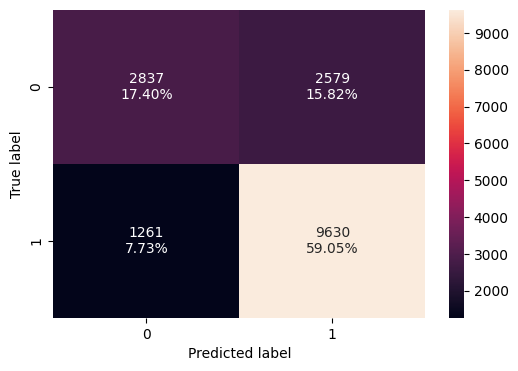

```python
# Plotting confusion matrix for tuned XGBoost Classifier on training data
confusion_matrix(xgboost_classifier_tuned, X_train, y_train)
```

**`Observations:`**

- The tuned XGBoost Classifier achieved a training accuracy of 0.7645, indicating that the model correctly classified around 76.45 percent of the training records.
- The precision score is 0.7888, meaning that when the model predicted an application as Certified, nearly 78.88 percent of those predictions were correct.
- The recall score is 0.8842, which shows that the model successfully identified most of the actual Certified applications in the training data.
- The F1 score is 0.8338, indicating a strong balance between precision and recall, with the model performing especially well in identifying the Certified class.
- From the confusion matrix, the model correctly classified 2,837 Denied cases and 9,630 Certified cases. However, 2,579 Denied cases were incorrectly predicted as Certified, and 1,261 Certified cases were incorrectly predicted as Denied.
- The model is more effective at identifying Certified applications than Denied applications, as the number of correctly predicted Certified cases is much higher.
- Compared with untuned XGBoost, the tuned model shows lower training performance, which is a positive sign because hyperparameter tuning has reduced overfitting and made the model less complex.
- Overall, the tuned XGBoost model provides a good balance between accuracy, precision, recall, and F1 score, but it still needs improvement in correctly identifying Denied cases.

### **Evaluation of model performance on the Validation Set**

```python
# Evaluating tuned XGBoost Classifier on validation data
xgboost_classifier_tuned_validation_perf = model_performance_evaluation(xgboost_classifier_tuned, X_val, y_val)

xgboost_classifier_tuned_validation_perf
```

|  | Accuracy | Precision | Recall | F1 Score |
| --- | --- | --- | --- | --- |
| 0 | 0.747363 | 0.776003 | 0.874036 | 0.822107 |

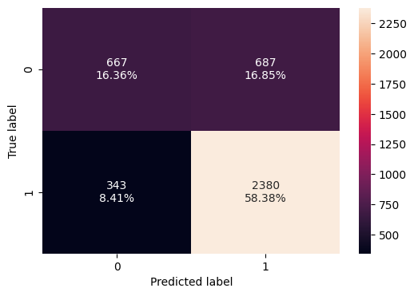

```python
# Plotting confusion matrix for tuned XGBoost Classifier on validation data
confusion_matrix(xgboost_classifier_tuned, X_val, y_val)
```

**`Observations:`**

- The tuned XGBoost Classifier achieved a validation accuracy of 0.7474, meaning the model correctly classified around 74.74 percent of validation records.
- The precision score is 0.7760, which indicates that when the model predicted an application as Certified, around 77.60 percent of those predictions were correct.
- The recall score is 0.8740, showing that the model successfully identified most of the actual Certified applications in the validation set.
- The F1 score is 0.8221, which reflects a strong balance between precision and recall and shows that the model performs well on unseen validation data.
- From the confusion matrix, the model correctly classified 667 Denied cases and 2,380 Certified cases. However, 687 Denied cases were incorrectly predicted as Certified, while 343 Certified cases were incorrectly predicted as Denied.
- The model performs better in identifying Certified applications than Denied applications, as the recall for the Certified class is high and the number of correctly predicted Certified cases is much larger.
- Compared with the training performance, the validation performance is very close, which indicates that the tuned XGBoost model generalizes well and does not show strong overfitting.
- Overall, the tuned XGBoost Classifier is a reliable model with strong recall and F1 score, but it still has room for improvement in reducing false positives for the Denied class.